# Exercise 5.3.3 - Elastic Net Regression

W. Mangrobang

August 28, 2018

### Breast Cancer Data Set

Use the breast cancer dataset (split into the training and test samples as before). The target variable is diagnosis.

1. Perform an elastic net regression using lambda values of 0.01,0.1, 1, and 10 and mixing coefficients of 0.25,0.5,and 0.75.
2. Compare the coefficient values for all of your models.
3. Test all of your models on the test data and compare the predictive accuracy.
4. Compare your results with ridge and lasso regressions.

#### Get data; set up training/test sets

```r
# load data
bc.all <- read.csv("/users/werlindo/dropbox/pacp/data/BreastCancerWisconsinDataSet.csv")

# take a look at data
print( 'Look at bc.all')
str(bc.all)

# create binarized target
bc.all$target [bc.all$diagnosis == "M"] = 1
bc.all$target [bc.all$diagnosis == "B"] = 0
bc.all$target <- as.factor(bc.all$target) # This is to force the logistic regression to predict 0/1

# select variables available for training
bc.all <- bc.all[, setdiff(colnames(bc.all), c("diagnosis", "id", "X"))]

# split data into training vs testing; 80%/20%
set.seed(2425)

library(caret) # get createDataPartition
train <- createDataPartition(bc.all$target, p = 0.8, list = FALSE)

bc.train <- bc.all[train, ]
bc.test <- bc.all[-train, ]

#take a quick look at train set
print( 'Look at bc.train')
str(bc.train)
```

[output not shown]

#### Perform a logistic **elastic net** regression using lambda values of 0.01, 0.1, 1, and 10, and alphas of 0.25, 0.5, and 0.75.

Since we’re going to use a loop, will also grab the coefficients now. Also, to take advantage of the loop, run through the test predictions as well.

```r
library(glmnet) #regressions

# # Set up the formula (model form)
# # #Know that target is last of 31 columns, so take 1:30
formula.lm <- as.formula(paste("target~",paste(colnames(bc.train[,c(1:30)]),collapse = "+")))

# #Here is a clever way to create the data matrix. This one doesn't require keeping track of which columns contain the features.
X <- model.matrix(formula.lm, data = bc.train)
X.test <- model.matrix(formula.lm, data = bc.test)

# Set up lambdas
lambdas <- c(0.01, 0.1, 1, 10)
alphas <- c(0.25, 0.5, 0.75)
counter = 1 #for loop helper
list.res.enet <- list() #List to store coefficients later

# Loop through the alphas and run elastic nets on the requested lambdas
for (a in alphas){
  # Run enet regressions
  bc.enet <- glmnet(X, y = bc.train$target
                           ,family = "binomial"
                           ,alpha = a
                           ,lambda = lambdas
                     )

  # append predictions onto train
  # get results matrix
  res.enet <- predict(bc.enet, newx = X, type="class")
  # res.enet

  # Remove the dimnames
  res.enet <- unname(res.enet)

  # Coerce to numeric
  res.enet <- apply(res.enet, 2, as.double)

  # turn into df
  res.enet <- as.data.frame(res.enet)

  # make readable names for predictions
  ll <- as.character(bc.enet$lambda)
  prefix <- rep.int('res.lam.',4)
  suffix <- rep.int(paste0('.a.', a) ,4)
  new.names <- paste0(prefix , ll, suffix)
  colnames(res.enet) <- new.names

  # Finally, bind the results to training set
  bc.train <- cbind( bc.train, res.enet )

  ##### Test predictions #####
  test.res.enet <- predict(bc.enet, newx = X.test, type="class")

  # Remove the dimnames
  test.res.enet <- unname(test.res.enet)

  # Coerce to numeric
  test.res.enet <- apply(test.res.enet, 2, as.double)

  # turn into df
  test.res.enet <- as.data.frame(test.res.enet)

  # get readable names for predictions
  colnames(test.res.enet) <- new.names

  # Finally, bind the results to training set
  bc.test <- cbind( bc.test, test.res.enet )

  ############################################################
  # Let's also get the coefficients of the regularized models
  bc.enet.betas <- bc.enet$beta

  # Save the names
  bc.enet.beta.names <- dimnames(bc.enet.betas)[[1]]

  # Transpose it
  bc.enet.betas <- t(bc.enet.betas)

  # Remove the dimnames
  bc.enet.betas <- unname(bc.enet.betas)

  # Coerce to regular matrix
  bc.enet.betas <- as.matrix(bc.enet.betas)

  # Coerce to data frame
  bc.enet.betas <- as.data.frame(bc.enet.betas)

  # Replace column names
  colnames(bc.enet.betas) <- bc.enet.beta.names

  # Add row name
  row.names(bc.enet.betas) <- new.names

  # Still the resulting dataframe in a list
  list.res.enet[[counter]] <- bc.enet.betas
  counter <- counter + 1
}
```

#### Get coefficients for all models

We’ll gather up coeffients for enet regression models and put them into a table.

```r
# Combine all coefs

library(kableExtra) #kable
library(tidyverse) #rownames_to_columns

res.coefs <- do.call("rbind",list.res.enet)
res.coefs <- rownames_to_column(res.coefs)
colnames(res.coefs)[1] <- 'model'

# Let's make a pretty table
coef.tbl <- res.coefs %>%
  kable() %>%
  kable_styling(bootstrap_options = "striped", font_size = 7) %>%
  row_spec(0, angle = 0)
coef.tbl
```

| model | (Intercept) | radius_mean | texture_mean | perimeter_mean | area_mean | smoothness_mean | compactness_mean | concavity_mean | concave.points_mean | symmetry_mean | fractal_dimension_mean | radius_se | texture_se | perimeter_se | area_se | smoothness_se | compactness_se | concavity_se | concave.points_se | symmetry_se | fractal_dimension_se | radius_worst | texture_worst | perimeter_worst | area_worst | smoothness_worst | compactness_worst | concavity_worst | concave.points_worst | … |
| --- | --- | --- | --- | --- | --- | --- | --- | --- | --- | --- | --- | --- | --- | --- | --- | --- | --- | --- | --- | --- | --- | --- | --- | --- | --- | --- | --- | --- | --- | --- |
| res.lam.10.a.0.25 | 0 | 0.0000000 | 0.0000000 | 0.0000000 | 0.0000000 | 0.0000000 | 0.0000000 | 0.0000000 | 0.000000 | 0 | 0.0000 | 0.0000000 | 0 | 0.0000000 | 0.0000000 | 0.000000 | 0.000000 | 0.0000000 | 0.00000 | 0.00000 | 0.00000 | 0.0000000 | 0.0000000 | 0.0000000 | 0.0000000 | 0.000000 | 0.0000000 | 0.0000000 | 0.000000 | … |
| res.lam.1.a.0.25 | 0 | 0.0075826 | 0.0000000 | 0.0013991 | 0.0000360 | 0.0000000 | 0.0000000 | 0.3640297 | 1.764146 | 0 | 0.0000 | 0.0000000 | 0 | 0.0000000 | 0.0000000 | 0.000000 | 0.000000 | 0.0000000 | 0.00000 | 0.00000 | 0.00000 | 0.0112961 | 0.0000000 | 0.0017621 | 0.0000503 | 0.000000 | 0.0000000 | 0.0543311 | 1.190216 | … |
| res.lam.0.1.a.0.25 | 0 | 0.0626626 | 0.0342208 | 0.0091895 | 0.0005061 | 0.9877369 | 0.3081992 | 2.1638202 | 8.162718 | 0 | 0.0000 | 0.4491491 | 0 | 0.0323506 | 0.0009186 | 0.000000 | 0.000000 | 0.0000000 | 0.00000 | 0.00000 | 0.00000 | 0.0640156 | 0.0398224 | 0.0088268 | 0.0004052 | 7.645737 | 0.6153475 | 0.8081966 | 5.513657 | … |
| res.lam.0.01.a.0.25 | 0 | 0.1068637 | 0.0978622 | 0.0146135 | 0.0009801 | 4.4009464 | 0.0000000 | 4.9469790 | 15.963287 | 0 | -16.0537 | 2.4070544 | 0 | 0.1842717 | 0.0080076 | 5.202362 | -20.211133 | -0.0217366 | 11.57745 | -18.60036 | -67.89190 | 0.1345495 | 0.1116668 | 0.0165762 | 0.0009354 | 18.384507 | 0.0000000 | 1.9382707 | 10.937638 | … |
| res.lam.10.a.0.5 | 0 | 0.0000000 | 0.0000000 | 0.0000000 | 0.0000000 | 0.0000000 | 0.0000000 | 0.0000000 | 0.000000 | 0 | 0.0000 | 0.0000000 | 0 | 0.0000000 | 0.0000000 | 0.000000 | 0.000000 | 0.0000000 | 0.00000 | 0.00000 | 0.00000 | 0.0000000 | 0.0000000 | 0.0000000 | 0.0000000 | 0.000000 | 0.0000000 | 0.0000000 | 0.000000 | … |
| res.lam.1.a.0.5 | 0 | 0.0000000 | 0.0000000 | 0.0000000 | 0.0000000 | 0.0000000 | 0.0000000 | 0.0000000 | 0.000000 | 0 | 0.0000 | 0.0000000 | 0 | 0.0000000 | 0.0000000 | 0.000000 | 0.000000 | 0.0000000 | 0.00000 | 0.00000 | 0.00000 | 0.0000000 | 0.0000000 | 0.0000000 | 0.0000000 | 0.000000 | 0.0000000 | 0.0000000 | 0.000000 | … |
| res.lam.0.1.a.0.5 | 0 | 0.0419546 | 0.0118053 | 0.0067365 | 0.0002011 | 0.0000000 | 0.0000000 | 1.8464597 | 9.487288 | 0 | 0.0000 | 0.0339798 | 0 | 0.0000000 | 0.0000000 | 0.000000 | 0.000000 | 0.0000000 | 0.00000 | 0.00000 | 0.00000 | 0.0670584 | 0.0340733 | 0.0092538 | 0.0003088 | 3.290928 | 0.1948516 | 0.6477346 | 6.712949 | … |
| res.lam.0.01.a.0.5 | 0 | 0.0936189 | 0.0824710 | 0.0120876 | 0.0007275 | 0.0000000 | 0.0000000 | 3.2243161 | 16.770452 | 0 | 0.0000 | 2.5710750 | 0 | 0.1326771 | 0.0048807 | 0.000000 | -14.689577 | 0.0000000 | 0.00000 | -8.13828 | -39.96367 | 0.1526206 | 0.1144656 | 0.0177656 | 0.0009199 | 17.954549 | 0.0000000 | 1.7090043 | 12.527672 | … |
| res.lam.10.a.0.75 | 0 | 0.0000000 | 0.0000000 | 0.0000000 | 0.0000000 | 0.0000000 | 0.0000000 | 0.0000000 | 0.000000 | 0 | 0.0000 | 0.0000000 | 0 | 0.0000000 | 0.0000000 | 0.000000 | 0.000000 | 0.0000000 | 0.00000 | 0.00000 | 0.00000 | 0.0000000 | 0.0000000 | 0.0000000 | 0.0000000 | 0.000000 | 0.0000000 | 0.0000000 | 0.000000 | … |
| res.lam.1.a.0.75 | 0 | 0.0000000 | 0.0000000 | 0.0000000 | 0.0000000 | 0.0000000 | 0.0000000 | 0.0000000 | 0.000000 | 0 | 0.0000 | 0.0000000 | 0 | 0.0000000 | 0.0000000 | 0.000000 | 0.000000 | 0.0000000 | 0.00000 | 0.00000 | 0.00000 | 0.0000000 | 0.0000000 | 0.0000000 | 0.0000000 | 0.000000 | 0.0000000 | 0.0000000 | 0.000000 | … |
| res.lam.0.1.a.0.75 | 0 | 0.0022176 | 0.0000000 | 0.0021601 | 0.0000000 | 0.0000000 | 0.0000000 | 0.5703382 | 11.365570 | 0 | 0.0000 | 0.0000000 | 0 | 0.0000000 | 0.0000000 | 0.000000 | 0.000000 | 0.0000000 | 0.00000 | 0.00000 | 0.00000 | 0.0819638 | 0.0249590 | 0.0111250 | 0.0000740 | 0.000000 | 0.0000000 | 0.3252665 | 9.148987 | … |
| res.lam.0.01.a.0.75 | 0 | 0.0688058 | 0.0592227 | 0.0064636 | 0.0001492 | 0.0000000 | 0.0000000 | 0.3693490 | 19.140771 | 0 | 0.0000 | 3.1751026 | 0 | 0.0042094 | 0.0000000 | 0.000000 | -6.637629 | 0.0000000 | 0.00000 | 0.00000 | -29.53173 | 0.2045484 | 0.1229647 | 0.0210727 | 0.0008909 | 14.535306 | 0.0000000 | 1.3682668 | 14.406560 | … |

As expected, as lambda increases, the coefficients shrink towards zero/get zeroed out.

Also, as alpha increases, all else being equal, coefficients get shrunk towards zero. For example, looking at just radius_mean at lambda = 0.01:

```r
kable(res.coefs[grep('lam.0.01',res.coefs$model),c('model','radius_mean')]) %>%
  kable_styling(bootstrap_options = "striped", font_size = 7)
```

|  | model | radius_mean |
| --- | --- | --- |
| 4 | res.lam.0.01.a.0.25 | 0.1068637 |
| 8 | res.lam.0.01.a.0.5 | 0.0936189 |
| 12 | res.lam.0.01.a.0.75 | 0.0688058 |

#### Let’s visualize as heatmap

Sorted left to right by increasing lambda, and in each group of lambdas, by increasing alpha.

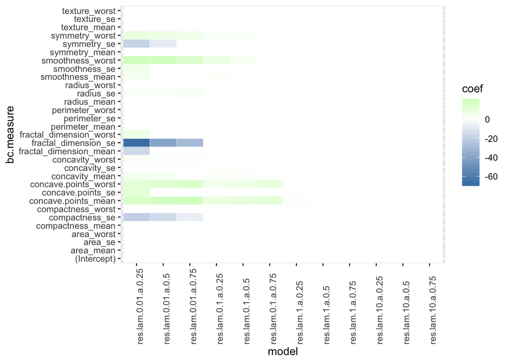

```r
library(tidyverse)
library(scales)

#Melt it
res_coefs.melt <- gather( res.coefs, key = bc.measure, value = coef, -model)

#Plot heatmap
p <- ggplot(res_coefs.melt, aes(x=model, y=bc.measure)) + geom_tile(aes(fill = coef),
     colour = "white") + scale_fill_gradient2(low = "steelblue",
     high = "green", mid = "white") +
     theme(axis.text.x = element_text(angle = 90, hjust = 0))
p
```

Again, as lambda increases (left to right), and as alpha increases (left to right) we get increasingly lighter towards white, which is around 0.

#### Calculate prediction accuracy of all the models on test set.

We’ll use a custom function for accuracy.

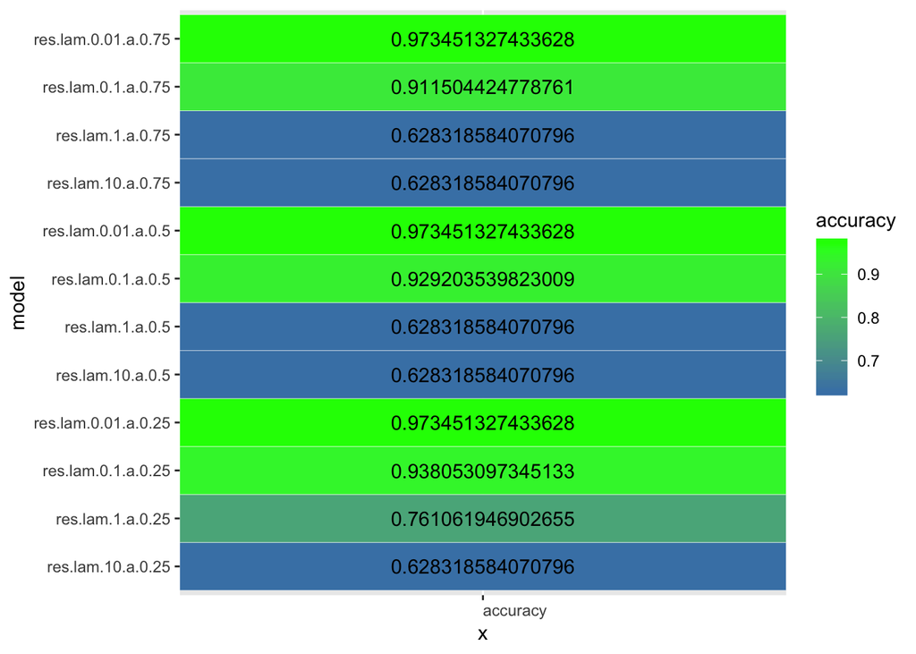

```r
accuracy = function(truth, pred) {
  # confusion matrix
  cmat = table(truth, pred)
  sum(diag(cmat))/sum(cmat)
}

#create empty dataframe to store accuracy results
acc <- data.frame( model=as.character(), accuracy=as.double())

#calc accuracy results
for ( m in res.coefs$model ){
  acc <- rbind(acc, data.frame( model=m, accuracy=accuracy(bc.test$target, bc.test[,m]) ))
}

#Plot heatmap
p <- ggplot(acc, aes(x='accuracy', y=model)) + geom_tile(aes(fill = accuracy),
     colour = "white") + scale_fill_gradient(high = "green", low = "steelblue") +
     theme(axis.text.x = element_text(angle = 0, hjust = 0)) +
     geom_text(aes(label=accuracy))
p
```

As we’ve seen with the [ridge](https://gitamoveon.github.io/PACP/Ex_5_3_1.html) and the [lasso](https://gitamoveon.github.io/PACP/Ex_5_3_2.html) analyses, as lambda increases we see decreasing accuracy as more variables get removed from the model. Thus the models have less information to predict with. All else equal with regards to the lambdas, these results should fall in between ridge and lasso.